# stac_airphoto_bc

[figure not shown]

The goal of [`stac_airphoto_bc`](https://github.com/NewGraphEnvironment/stac_airphoto_bc) is to serve georeferenced historical aerial photograph thumbnails for British Columbia as a [STAC](https://stacspec.org/) collection. Currently covering the Neexdzii Kwa (Upper Bulkley River) watershed and three small southeast BC areas, 10,100 photos spanning 1967–2019. Queryable by location and time via [`rstac`](https://brazil-data-cube.github.io/rstac/) and [QGIS (v3.42+)](https://qgis.org/) at https://images.a11s.one.

This work is built on the [`fly`](https://github.com/NewGraphEnvironment/fly) R package which handles airphoto footprint estimation, spatial filtering, thumbnail downloading, and georeferencing. Sister collections on the same endpoint:

- [`stac_dem_bc`](https://github.com/NewGraphEnvironment/stac_dem_bc) — LidarBC digital elevation models (~58k GeoTIFFs)
- [`stac_uav_bc`](https://github.com/NewGraphEnvironment/stac_uav_bc) — UAV imagery organized by region / watershed-group / year

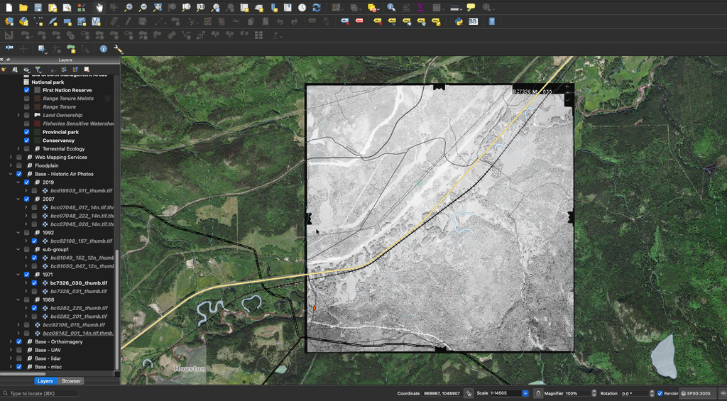

## Pipeline

Source centroids from the [BC Data Catalogue](https://catalogue.data.gov.bc.ca/dataset/bc-air-photo-centroids), process through five stages:

| Step | Script | What |
| --- | --- | --- |
| Fetch | `01_fetch.R` | Query centroids, size DEM-corrected footprints, assign per-roll rotation and placement, select, download thumbnails |
| Georef | `02_georef.R` | Warp thumbnails to their footprints (BC Albers, EPSG:3005) |
| COG | `03_cog.py` | Apply the measured placement shift, embed metadata tags, write each Cloud-Optimized GeoTIFF once |
| STAC | `05_stac_register.py` | Generate items with checksums and provenance, merge into the collection, validate |
| S3 | `04_s3_upload.R` | Re-check every item against its COG, back up the published item JSONs, sync |

Run end-to-end: `bash scripts/run_pipeline.sh`

Each COG carries embedded metadata (visible in QGIS layer properties): `AIRP_ID`, `PHOTO_DATE`, `SCALE`, `FILM_ROLL`, `FRAME_NUMBER`, `FOCAL_LENGTH`, `FLYING_HEIGHT`, `FILENAME`, and how it was placed: `ROTATION`, `ROTATION_SOURCE`, `PLACEMENT_SOURCE`, `SHIFT_X_M_3005`, `SHIFT_Y_M_3005`, `HEIGHT_SOURCE`, `FOOTPRINT_BASIS`, `FLY_VERSION`, `FLY_SHA`, `PIPELINE_SHA`.

### How each frame is placed

Footprints come from [`fly`](https://github.com/NewGraphEnvironment/fly), sized with a DEM (MRDEM-30): checked against the province’s published photogrammetric solutions it agrees on width to 0–2%, and without it film is about 9% too small. Two measured corrections from a separate validation against provincial orthophotos are then applied, and every item says where its values came from, so frames can be filtered and checked:

- `airphoto:rotation_source` — how the scanned image sits on its footprint, a per-roll constant: `measured` (fitted against orthophotos), `reviewed` (a person looked), `disputed` (a person disagrees with the measured value, kept and flagged), or `assumed_by_series` (no measurement; the default for the roll’s series). Absent on digital frames, whose orientation `fly` derives itself.
- `airphoto:placement_source` — a per-frame shift in EPSG:3005 metres (`airphoto:shift_x_m_3005`, `airphoto:shift_y_m_3005`): `correlator` (the frame’s own fit), `roll_model` (the roll’s measured bias, only where held-out frames confirm it), `manual`, or `none` (where the catalogue puts it).
- `airphoto:height_source` — whether `fly` used the catalogue’s flying height, repaired a known unit slip, or refused an implausible one.

Each thumbnail asset carries `file:checksum` (a sha256 multihash) and `file:size`, and each item the `fly` build and pipeline commit that made it, in the [processing extension](https://github.com/stac-extensions/processing): `processing:software` (`{"fly": "<version>+<sha>"}`), `processing:version` (the pipeline commit) and `processing:datetime` (when the COG was written). Items published before the rebuild that carries #47 hold the same values as `nge:` fields; see NEWS.

```r
# frames with a photogrammetric solution
rstac::stac_search(
  q, collections = "stac-airphoto-bc", limit = 100
) |> rstac::ext_filter(`airphoto:georef_metadata` == TRUE)
```

## Query with rstac

```r
library(rstac)
library(sf)

# AOIs come from the registry in scripts/aoi.R, not from constants here.
# Swap the id for any other registered area — se_a, se_b, se_c.
source("scripts/aoi.R")
aoi <- aoi_resolve("neexdzii_kwa") |> sf::st_transform(4326)

# Search for photos between 1965 and 1975
q <- rstac::stac("https://images.a11s.one/") |>
  rstac::stac_search(
    collections = "stac-airphoto-bc",
    intersects = jsonlite::fromJSON(
      geojsonsf::sf_geojson(aoi, atomise = TRUE, simplify = FALSE),
      simplifyVector = FALSE
    ) |> (\(x) x$geometry)(),
    datetime = "1965-01-01T00:00:00Z/1975-12-31T00:00:00Z"
  ) |>
  rstac::post_request()

r <- q |> rstac::items_fetch()

saveRDS(r, "data/stac_result.rds")
```

```r
r <- readRDS("data/stac_result.rds")

tab <- tibble::tibble(
  title = purrr::map_chr(r$features, ~ purrr::pluck(.x, "properties", "title", .default = .x$id)),
  url = purrr::map_chr(r$features, ~ purrr::pluck(.x, "assets", "thumbnail", "href"))
) |>
  dplyr::mutate(
    link_view = ngr::ngr_str_link_url(
      url_base = "https://viewer.a11s.one/?cog=",
      url_resource = url,
      url_resource_path = FALSE,
      anchor_text = title
    ),
    link_download = ngr::ngr_str_link_url(
      url_base = url,
      anchor_text = basename(url)
    )
  ) |>
  dplyr::select(link_view, link_download)
```

|  | link_view | link_download |
| --- | --- | --- |
| 1 | 1268039 — bc7824_167 — 1975-09-18 | bc7824_167_thumb.tif |
| 2 | 1268038 — bc7824_166 — 1975-09-18 | bc7824_166_thumb.tif |
| 3 | 1268037 — bc7824_165 — 1975-09-18 | bc7824_165_thumb.tif |
| 4 | 1268036 — bc7824_164 — 1975-09-18 | bc7824_164_thumb.tif |
| 5 | 1268035 — bc7824_163 — 1975-09-18 | bc7824_163_thumb.tif |
| 6 | 1268034 — bc7824_162 — 1975-09-18 | bc7824_162_thumb.tif |
| 7 | 1268033 — bc7824_161 — 1975-09-18 | bc7824_161_thumb.tif |
| 8 | 1268032 — bc7824_160 — 1975-09-18 | bc7824_160_thumb.tif |
| 9 | 1268031 — bc7824_159 — 1975-09-18 | bc7824_159_thumb.tif |
| 10 | 1268030 — bc7824_158 — 1975-09-18 | bc7824_158_thumb.tif |

[output cut: 1633 more lines]

## QGIS Integration

As of QGIS 3.42, STAC items can be accessed directly via the Data Source Manager. Connect to `https://images.a11s.one` and browse the `stac-airphoto-bc` collection. See [this blog](https://www.lutraconsulting.co.uk/blogs/stac-in-qgis) for details.

Items display with descriptive titles (`airp_id -- roll_frame -- date`) for easy identification:

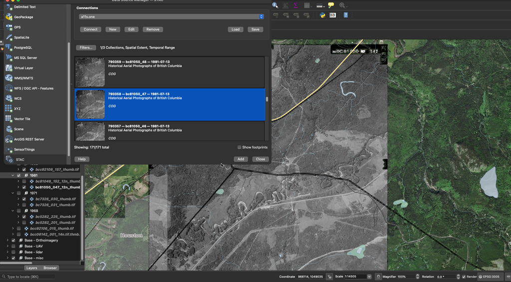

Browsing the airphoto collection in QGIS STAC Data Source Manager

## Roadmap

- **Area expansion** — the collection covers the Neexdzii Kwa watershed and three small southeast BC areas (10,100 photos, 1967–2019). The pipeline is parameterized by AOI, so adding an area is mostly a fetch + georef + register cycle.
- **Measured placement beyond the validated area** — per-roll rotation and per-frame shifts come from a validation against orthophotos in and around Neexdzii Kwa; elsewhere rotation follows a per-series default, labelled `assumed_by_series`, and frames stay where the catalogue puts them. Extending the measurement is how those labels change.
- **Shared STAC-infrastructure direction** — improvements landing in the sister `stac_*_bc` repos (true-footprint geometry, uv-based Python dependency management, structured logging + benchmarking) apply here too.

Browse [open issues](https://github.com/NewGraphEnvironment/stac_airphoto_bc/issues) for the current backlog.

## Related

- [`fly`](https://github.com/NewGraphEnvironment/fly) – R package for airphoto footprints, filtering, fetching, and georeferencing
- [`stac_dem_bc`](https://github.com/NewGraphEnvironment/stac_dem_bc) – British Columbia LidarBC DEM collection
- [`stac_uav_bc`](https://github.com/NewGraphEnvironment/stac_uav_bc) – UAV imagery collection
- images.a11s.one – STAC API endpoint